# visualizing effects of stan covariance prior parameters

[this](http://mc-stan.org/rstanarm/articles/glmer.html) is probably the best description.

- `shape`, `scale`: distribution of *overall* variance (“football size” = trace = sum of eigenvalues = $J \tau^2$, where $J$ is the dimension/order of the cov matrix). The Gamma prior is on $\tau$.
  - small → large scale: small to large overall mean *and* variance (mean=shape × scale; var = shape × scale^2)
  - small → large shape: large coefficient of variation to small CV (var/mean^2 = CV^2 = 1/shape → shape = 1/CV^2)
- `concentration`: distribution of division of overall variance into components (“stretching along the axes”). Parameter of symmetric Dirichlet distribution. Small = very unequal distribution; 1 = ‘flat’ distribution; large = equal partitioning of variance across components
- `regularization`: *something* about the rotation/orientation of the football (LKJ prior = measure on determinant of correlation matrix = measure of ‘skinniness’ of the football). small: identity matrix is most *unlikely* (trough); 1: ‘flat’ across correlation space; large: identity matrix is most likely ($\textrm{det}(\Omega)^{\zeta-1}$)

I don’t know, but I’m suspecting that concentration and regularization are *jointly* contributing to the non-sphericity:

- A very small concentration parameter (variance tends to be concentrated in one component) combined with a large regularization parameter (independent correlation matrix) will give a shape that is elongated along some axes and shrunk along others.
- A very *large* concentration parameter (equal variance in all components) and a very *small* regularization parameter (correlation matrices with strong correlations) will still give a sphere (if the variance is equal, it doesn’t really matter how we rotate it)
- Maybe regularization is really only about rotation? (Although there’s still something I don’t understand - a strong (±1) correlation is skinny even if the original variances are equal?)

Need to draw some pictures.

Strategy: use `stan_lmer` with `prior_PD=TRUE` to generate prior samples from the prior distribution of covariance matrices. Draw them. We probably only need a small number of iterations. (How do we do it without getting warnings? Do we care? `warmup=1000, iter = 1025` ?)

```r
library(rstanarm)
library(tidyverse)
theme_set(theme_bw())
library(ellipse)
library(cowplot)
data("sleepstudy", package = "lme4")
```

Basic example using `sleepstudy` data (I think the data don’t really matter for the application here, just the dimension of the random effect - and maybe the variance etc. of the terms? Don’t know whether any autoscaling is done for the random effects terms …)

```r
s1 <- stan_lmer(Reaction ~ 1 + (Days|Subject), data=sleepstudy,
                prior_PD =TRUE,
                prior_covariance = decov(shape=1, scale=1, regularization=1, concentration=1),
                refresh=0  ## silent
                )
```

```r
dd <- (s1$stanfit
    %>% as.data.frame()
    %>% as_tibble()
    %>% select(starts_with("Sigma", ignore.case = FALSE))
)
```

Compute covariance matrices → ellipses etc. → plot for this example

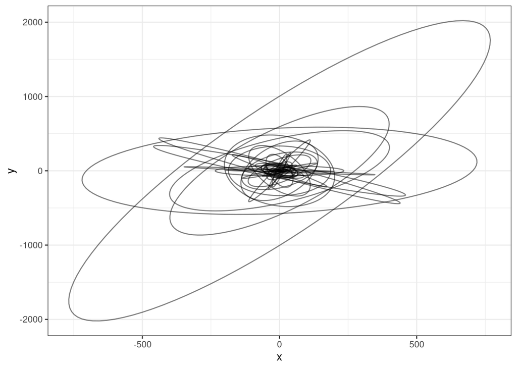

```r
mk_covmat <- function(v) {
    n <- (sqrt(8*length(v)+1)-1)/2   ## matrix dim given lower-triangle (w/ diag) vector
    m <- matrix(NA, n, n)
    m[lower.tri(m, diag=TRUE)] <- v  ## set lower triangle
    m[upper.tri(m)] <- t(m)[upper.tri(m)] ## symmetrize
    return(m)
}
m <- mk_covmat(as.numeric(dd[1,]))
e <- ellipse(m)
nsamp <- 50
res <- setNames(vector("list", nsamp), 1:nsamp)
for (i in 1:nsamp) {
    res[[i]] <- as_tibble(ellipse(mk_covmat(as.numeric(dd[i,]))))
}
res <- bind_rows(res, .id="row")
ggplot(res, aes(x,y, group = row)) + geom_path(alpha=0.5)
```

```r
#' @param ... arguments to decov()
#' @param nsamp number of samples to save
#' @param seed random-number seed for Stan sampling
#' @param title_width width of plot title (NA to suppress plot title)
mk_covprior_2d <- function(..., nsamp = 50, seed = 101, title_width = 25) {
    ## set up dummy data set for model
    d0 <- data.frame(y = 1:100, x1 = 1:100, x2 = 1:100,
                     g = factor(rep(1:10, 10)))
    ## run model (the only thing that should matter here is
    ##  the dimensionality of the random effect ... ?
    s1 <- stan_lmer(y ~ 1 + (1+x1|g), data=d0,
                    prior_PD =TRUE,
                    prior_covariance = decov(...),
                    seed = seed,
                    refresh=0  ## silent
                    )
    ## extract covariance parameters
    dd <- (s1$stanfit
        %>% as.data.frame()
        %>% as_tibble()
        %>% select(starts_with("Sigma", ignore.case = FALSE))
    )
    ## compute cov matrices and ellipses
    cc <- ee <- setNames(vector("list", nsamp), 1:nsamp)
    for (i in 1:nsamp) {
        cc[[i]] <- mk_covmat(as.numeric(dd[i,]))
        ee[[i]] <- as_tibble(ellipse(cc[[i]]))

    }
    ee <- bind_rows(ee, .id="row")
    res <- list(fit = s1$stanfit,
                samples = dd,
                covmats = cc,
                ellipses = ee,
                gg = (ggplot(ee, aes(x,y, group = row))
                    + geom_path(alpha=0.5)
                    + coord_equal()
                    + labs(x="", y="")
                )
                )
    if (!is.na(title_width)) {
        args <- list(...)
        dca <- formals(rstanarm::decov)
        for (n in names(args)) {
            dca[[n]] <- args[[n]]
        }
        t_str <- paste(names(dca), dca, sep="=", collapse=", ")
        t_str <- paste(strwrap(t_str, title_width), collapse = "\n")
        res$gg <- res$gg+ ggtitle(t_str)
    }
    class(res) <- c("covprior_sample", class(res))
    return(res)
}

## return trace distribution; could also return determinant distribution?
summary.covprior_sample <- function(x) {
    eigs <- t(sapply(x$covmats,
                     function(x) eigen(x, only.values = TRUE)$values))
    ## compute trace, SD of eigenvalues, determinant?
    tracevec <- rowSums(eigs)
    list(trace = summary(tracevec))
}
```

```r
## cache = TRUE, depends.on = "plotfun"}
bigval <- 1e4
v_bigval <- 5e4
p_basic <-   mk_covprior_2d()
p_testscale <-   mk_covprior_2d(shape= bigval, scale = 1)
p_fixvar <-  mk_covprior_2d(shape = bigval, scale = 1/bigval)
p_fixvar2 <- mk_covprior_2d(shape = bigval, scale = 1/bigval, concentration = bigval)
p_round <-   mk_covprior_2d(shape = bigval, scale = 1/bigval, concentration = bigval,
                            regularization = bigval)
p_reg <- mk_covprior_2d(shape = bigval, scale = 1/bigval,
                     regularization = bigval)
p_small <-   mk_covprior_2d(shape = bigval, scale = 1/(v_bigval),
                            concentration = bigval,
                            regularization = bigval)
```

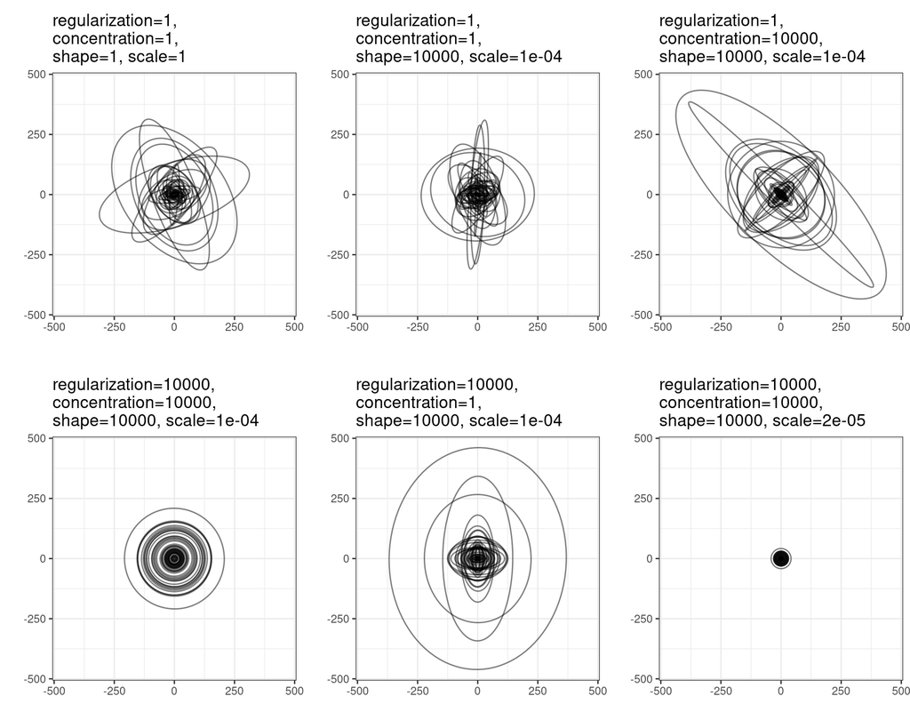

```r
p_list <- tibble::lst(p_basic, p_fixvar, p_fixvar2, p_round, p_reg, p_small)

maxval <- max(purrr:::map_dbl(p_list,
                          ~ max(abs(.$ellipses$x), abs(.$ellipses$y))))
plot_list <- lapply(p_list,
                    function(x) x$gg + expand_limits(x=c(-maxval, maxval),
                                                     y=c(-maxval, maxval)))
plot_grid(plotlist = plot_list)
```

```r
print(do.call(rbind,sapply(p_list, summary)), digits=3)
```

```
##                    Min. 1st Qu. Median Mean 3rd Qu.  Max.
## p_basic.trace   3.18707  101.55    615 3118    2587 25164
## p_fixvar.trace  0.00153  260.47    930 2459    1851 16339
## p_fixvar2.trace 0.12868  106.35    427 5036    4204 63396
## p_round.trace   0.62032  168.57    501 1975    2791 14492
## p_reg.trace     0.29048  181.59    700 3097    2368 58175
## p_small.trace   0.02481    6.74     20   79     112   580
```

## to do

- figure out what’s going on with shape/scale: why doesn’t setting shape large, shape*scale = 1 fix the variance as expected ??? If $\tau \sim \textrm{Gamma}(\textrm{shape}, \textrm{scale})$ and we set `shape` large and `scale`=`1/shape` (so that the mean is 1 and the CV is small), we should get trace = sum of eigenvalues = $J\tau^2$ = 2. Instead we get

```r
summary(p_fixvar)
```

```
## $trace
##      Min.   1st Qu.    Median      Mean   3rd Qu.      Max.
##     0.002   260.470   929.851  2459.309  1850.675 16338.802
```